# Introduction

Ola is a leading ride-sharing platform, aiming to provide reliable, affordable, and convenient urban transportation for everyone. The constant challenge Ola faces is the churn rate of its drivers. Ensuring driver loyalty and reducing attrition are crucial to the company's operation. Analyzing driver data can reveal patterns in driver behavior, performance, and satisfaction. This would help in foreseeing potential churn, allowing proactive measures. By leveraging data science and ensemble learning, Ola can predict driver churn, which would be pivotal in its driver retention strategy.

### What is expected

Assuming you are a data scientist at Ola, you are entrusted with the responsibility of analyzing the dataset to predict driver attrition. Your primary goal is to utilize ensemble learning techniques, evaluate the performance of your models, and provide actionable insights to reduce driver churn.

# 1. Data

The analysis was done on the data located at - https://d2beiqkhq929f0.cloudfront.net/public_assets/assets/000/002/492/original/ola_driver_scaler.csv

# 2. Libraries

Below are the libraries required

```python
# libraries to analyze data
import numpy as np
import pandas as pd

# libraries to visualize data
import matplotlib.pyplot as plt
import seaborn as sns

import statsmodels.api as sm
from statsmodels.stats.outliers_influence import variance_inflation_factor

from sklearn.preprocessing import OneHotEncoder, MinMaxScaler, label_binarize
from sklearn.model_selection import train_test_split, RandomizedSearchCV, GridSearchCV, validation_curve
from sklearn.ensemble import RandomForestClassifier, GradientBoostingClassifier
from sklearn.metrics import classification_report, accuracy_score, confusion_matrix, ConfusionMatrixDisplay, roc_curve, auc, precision_recall_curve, average_precision_score
from sklearn.multiclass import OneVsRestClassifier

from imblearn.over_sampling import SMOTE

from scipy.stats import randint

from xgboost import XGBClassifier

from lightgbm import LGBMClassifier
```

# 3. Data Loading

Loading the data into Pandas dataframe for easily handling of data

```python
# read the file into a pandas dataframe
df = pd.read_csv('ola_driver_scaler.csv')
# look at the datatypes of the columns
print('*************************************************')
print(df.info())
print('*************************************************\n')
print('*************************************************')
print(f'Shape of the dataset is {df.shape}')
print('*************************************************\n')
print('*************************************************')
print(f'Number of nan/null values in each column: \n{df.isna().sum()}')
print('*************************************************\n')
print('*************************************************')
print(f'Number of unique values in each column: \n{df.nunique()}')
print('*************************************************\n')
print('*************************************************')
print(f'Duplicate entries: \n{df.duplicated().value_counts()}')
```

```
<class 'pandas.core.frame.DataFrame'>
RangeIndex: 19104 entries, 0 to 19103
Data columns (total 14 columns):
 #   Column                Non-Null Count  Dtype
---  ------                --------------  -----
 0   Unnamed: 0            19104 non-null  int64
 1   MMM-YY                19104 non-null  object
 2   Driver_ID             19104 non-null  int64
 3   Age                   19043 non-null  float64
 4   Gender                19052 non-null  float64
 5   City                  19104 non-null  object
 6   Education_Level       19104 non-null  int64
 7   Income                19104 non-null  int64
 8   Dateofjoining         19104 non-null  object
 9   LastWorkingDate       1616 non-null   object
 10  Joining Designation   19104 non-null  int64
 11  Grade                 19104 non-null  int64
 12  Total Business Value  19104 non-null  int64
 13  Quarterly Rating      19104 non-null  int64
dtypes: float64(2), int64(8), object(4)
memory usage: 2.0+ MB
None

Shape of the dataset is (19104, 14)

Number of nan/null values in each column:
Unnamed: 0                  0
MMM-YY                      0
Driver_ID                   0
Age                        61
Gender                     52
City                        0
Education_Level             0
Income                      0
Dateofjoining               0
LastWorkingDate         17488
Joining Designation         0
Grade                       0
Total Business Value        0
Quarterly Rating            0
dtype: int64

Number of unique values in each column:
Unnamed: 0              19104
MMM-YY                     24
Driver_ID                2381
Age                        36
Gender                      2
City                       29
Education_Level             3
Income                   2383
Dateofjoining             869
LastWorkingDate           493
Joining Designation         5
Grade                       5
Total Business Value    10181
Quarterly Rating            4
dtype: int64

Duplicate entries:
False    19104
Name: count, dtype: int64
```

```python
# look at the top 20 rows
df.head(20)
```

|  | Unnamed: 0 | MMM-YY | Driver_ID | Age | Gender | City | Education_Level | Income | Dateofjoining | LastWorkingDate | Joining Designation | Grade | Total Business Value | Quarterly Rating |
| --- | --- | --- | --- | --- | --- | --- | --- | --- | --- | --- | --- | --- | --- | --- |
| 0 | 0 | 01/01/19 | 1 | 28.0 | 0.0 | C23 | 2 | 57387 | 24/12/18 | NaN | 1 | 1 | 2381060 | 2 |
| 1 | 1 | 02/01/19 | 1 | 28.0 | 0.0 | C23 | 2 | 57387 | 24/12/18 | NaN | 1 | 1 | -665480 | 2 |
| 2 | 2 | 03/01/19 | 1 | 28.0 | 0.0 | C23 | 2 | 57387 | 24/12/18 | 03/11/19 | 1 | 1 | 0 | 2 |
| 3 | 3 | 11/01/20 | 2 | 31.0 | 0.0 | C7 | 2 | 67016 | 11/06/20 | NaN | 2 | 2 | 0 | 1 |
| 4 | 4 | 12/01/20 | 2 | 31.0 | 0.0 | C7 | 2 | 67016 | 11/06/20 | NaN | 2 | 2 | 0 | 1 |
| 5 | 5 | 12/01/19 | 4 | 43.0 | 0.0 | C13 | 2 | 65603 | 12/07/19 | NaN | 2 | 2 | 0 | 1 |
| 6 | 6 | 01/01/20 | 4 | 43.0 | 0.0 | C13 | 2 | 65603 | 12/07/19 | NaN | 2 | 2 | 0 | 1 |
| 7 | 7 | 02/01/20 | 4 | 43.0 | 0.0 | C13 | 2 | 65603 | 12/07/19 | NaN | 2 | 2 | 0 | 1 |
| 8 | 8 | 03/01/20 | 4 | 43.0 | 0.0 | C13 | 2 | 65603 | 12/07/19 | NaN | 2 | 2 | 350000 | 1 |
| 9 | 9 | 04/01/20 | 4 | 43.0 | 0.0 | C13 | 2 | 65603 | 12/07/19 | 27/04/20 | 2 | 2 | 0 | 1 |
| 10 | 10 | 01/01/19 | 5 | 29.0 | 0.0 | C9 | 0 | 46368 | 01/09/19 | NaN | 1 | 1 | 0 | 1 |
| 11 | 11 | 02/01/19 | 5 | 29.0 | 0.0 | C9 | 0 | 46368 | 01/09/19 | NaN | 1 | 1 | 120360 | 1 |
| 12 | 12 | 03/01/19 | 5 | 29.0 | 0.0 | C9 | 0 | 46368 | 01/09/19 | 03/07/19 | 1 | 1 | 0 | 1 |
| 13 | 13 | 08/01/20 | 6 | 31.0 | 1.0 | C11 | 1 | 78728 | 31/07/20 | NaN | 3 | 3 | 0 | 1 |
| 14 | 14 | 09/01/20 | 6 | 31.0 | 1.0 | C11 | 1 | 78728 | 31/07/20 | NaN | 3 | 3 | 0 | 1 |
| 15 | 15 | 10/01/20 | 6 | 31.0 | 1.0 | C11 | 1 | 78728 | 31/07/20 | NaN | 3 | 3 | 0 | 2 |
| 16 | 16 | 11/01/20 | 6 | 31.0 | 1.0 | C11 | 1 | 78728 | 31/07/20 | NaN | 3 | 3 | 1265000 | 2 |
| 17 | 17 | 12/01/20 | 6 | 31.0 | 1.0 | C11 | 1 | 78728 | 31/07/20 | NaN | 3 | 3 | 0 | 2 |
| 18 | 18 | 09/01/20 | 8 | 34.0 | 0.0 | C2 | 0 | 70656 | 19/09/20 | NaN | 3 | 3 | 0 | 1 |
| 19 | 19 | 10/01/20 | 8 | 34.0 | 0.0 | C2 | 0 | 70656 | 19/09/20 | NaN | 3 | 3 | 0 | 1 |

```python
df.describe()
```

|  | Unnamed: 0 | Driver_ID | Age | Gender | Education_Level | Income | Joining Designation | Grade | Total Business Value | Quarterly Rating |
| --- | --- | --- | --- | --- | --- | --- | --- | --- | --- | --- |
| count | 19104.000000 | 19104.000000 | 19043.000000 | 19052.000000 | 19104.000000 | 19104.000000 | 19104.000000 | 19104.000000 | 1.910400e+04 | 19104.000000 |
| mean | 9551.500000 | 1415.591133 | 34.668435 | 0.418749 | 1.021671 | 65652.025126 | 1.690536 | 2.252670 | 5.716621e+05 | 2.008899 |
| std | 5514.994107 | 810.705321 | 6.257912 | 0.493367 | 0.800167 | 30914.515344 | 0.836984 | 1.026512 | 1.128312e+06 | 1.009832 |
| min | 0.000000 | 1.000000 | 21.000000 | 0.000000 | 0.000000 | 10747.000000 | 1.000000 | 1.000000 | -6.000000e+06 | 1.000000 |
| 25% | 4775.750000 | 710.000000 | 30.000000 | 0.000000 | 0.000000 | 42383.000000 | 1.000000 | 1.000000 | 0.000000e+00 | 1.000000 |
| 50% | 9551.500000 | 1417.000000 | 34.000000 | 0.000000 | 1.000000 | 60087.000000 | 1.000000 | 2.000000 | 2.500000e+05 | 2.000000 |
| 75% | 14327.250000 | 2137.000000 | 39.000000 | 1.000000 | 2.000000 | 83969.000000 | 2.000000 | 3.000000 | 6.997000e+05 | 3.000000 |
| max | 19103.000000 | 2788.000000 | 58.000000 | 1.000000 | 2.000000 | 188418.000000 | 5.000000 | 5.000000 | 3.374772e+07 | 4.000000 |

```python
df.describe(include='object')
```

|  | MMM-YY | City | Dateofjoining | LastWorkingDate |
| --- | --- | --- | --- | --- |
| count | 19104 | 19104 | 19104 | 1616 |
| unique | 24 | 29 | 869 | 493 |
| top | 01/01/19 | C20 | 23/07/15 | 29/07/20 |
| freq | 1022 | 1008 | 192 | 70 |

### Insight

- There are **19104** entries with 14 columns
- There are **61 null/missing values in *Age*, 52 in *Gender* and 17488 in *LastWorkingDate***
- There are **2381 unique drivers**
- There are no **duplicates**
- The column **Unnamed: 0** can be dropped as it doesnt provide any new information
- The columns **Gender, City, Education_Level, Joining Designation, Grade** and **Quarterly Rating** can be converted to **categorical** datatype
- The columns **MMM-YY, Dateofjoining** and **LastWorkingDate** can be converted to **datetime** datatype
- Drivers who have valid **LastWorkingDate** can be considered as **churned**

```python
# Drop "Unnamed: 0" column
df.drop(columns=['Unnamed: 0'], inplace=True)

# Convert to category
categorical_columns = ['Gender', 'City', 'Education_Level', 'Joining Designation', 'Grade']
df[categorical_columns] = df[categorical_columns].astype('category')
df['Gender'].replace({0.0:'Male', 1.0: 'Female'}, inplace=True)
df['Education_Level'].replace({0:'10+', 1:'12+', 2:'Graduate'}, inplace=True)

# Convert to datetime
df['MMM-YY'] = pd.to_datetime(df['MMM-YY'], format='%m/%d/%y')
df['Dateofjoining'] = pd.to_datetime(df['Dateofjoining'], format='%d/%m/%y')
df['LastWorkingDate'] = pd.to_datetime(df['LastWorkingDate'], format='%d/%m/%y')

# Rename 'MMM-YY' to 'ReportingMonthYear'
df.rename(columns={'MMM-YY':'ReportingMonthYear'}, inplace=True)
df['ReportingMonthYear'] = df['ReportingMonthYear'].dt.to_period('M')
df['ReportingYear'] = df['ReportingMonthYear'].dt.year

# Extract month and year from 'Dateofjoining'
df['Monthofjoining'] = df['Dateofjoining'].dt.month
df['Yearofjoining'] = df['Dateofjoining'].dt.year

# Find drivers who haved churned
df['Churn'] = df.groupby('Driver_ID')['LastWorkingDate'].transform('last')
df['Churn'] = df['Churn'].apply(lambda x: 0 if pd.isnull(x) else 1)

df.info()
```

[output not shown]

```python
# look at the top 5 rows
df.head(5)
```

|  | ReportingMonthYear | Driver_ID | Age | Gender | City | Education_Level | Income | Dateofjoining | LastWorkingDate | Joining Designation | Grade | Total Business Value | Quarterly Rating | ReportingYear | Monthofjoining | Yearofjoining | Churn |
| --- | --- | --- | --- | --- | --- | --- | --- | --- | --- | --- | --- | --- | --- | --- | --- | --- | --- |
| 0 | 2019-01 | 1 | 28.0 | Male | C23 | Graduate | 57387 | 2018-12-24 | NaT | 1 | 1 | 2381060 | 2 | 2019 | 12 | 2018 | 1 |
| 1 | 2019-02 | 1 | 28.0 | Male | C23 | Graduate | 57387 | 2018-12-24 | NaT | 1 | 1 | -665480 | 2 | 2019 | 12 | 2018 | 1 |
| 2 | 2019-03 | 1 | 28.0 | Male | C23 | Graduate | 57387 | 2018-12-24 | 2019-11-03 | 1 | 1 | 0 | 2 | 2019 | 12 | 2018 | 1 |
| 3 | 2020-11 | 2 | 31.0 | Male | C7 | Graduate | 67016 | 2020-06-11 | NaT | 2 | 2 | 0 | 1 | 2020 | 6 | 2020 | 0 |
| 4 | 2020-12 | 2 | 31.0 | Male | C7 | Graduate | 67016 | 2020-06-11 | NaT | 2 | 2 | 0 | 1 | 2020 | 6 | 2020 | 0 |

# 4. Exploratory Data Analysis

## 4.1. Univariate analysis

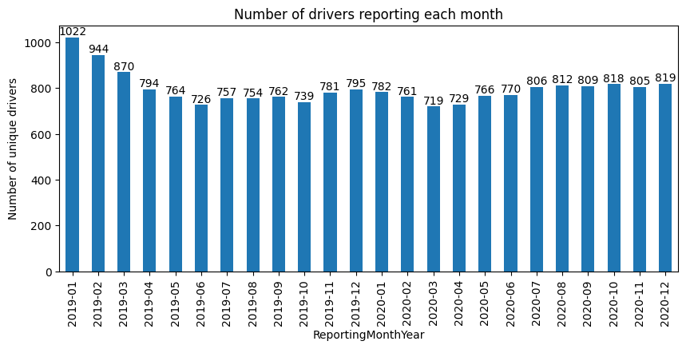

```python
plt.figure(figsize=(10,4))
temp_df = df.groupby('ReportingMonthYear')['Driver_ID'].nunique()
ax = temp_df.plot(kind='bar')
ax.bar_label(ax.containers[0])
plt.ylabel('Number of unique drivers')
plt.title('Number of drivers reporting each month')
plt.show()
```

### Insight

- The **month** during which **maximum** number of **drivers reported is January 2019**. A total of **1022 drivers** reported on January 2019
- It then dropeed every month after January and has been stagnant at around 800 drivers reported every month

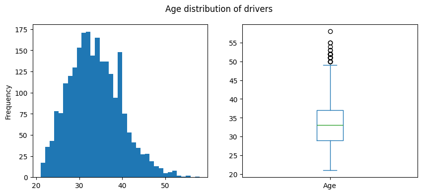

```python
fig, axs = plt.subplots(1,2,figsize=(10,4))
temp_df = df.groupby('Driver_ID').agg({'Age':'last'})['Age']
temp_df.plot(ax=axs[0], kind='hist', bins=35)
temp_df.plot(ax=axs[1], kind='box')
fig.suptitle('Age distribution of drivers')
plt.show()
```

### Insight

- There are drivers from different **age** groups ranging from **21 to 58 years**
- **Most** of the drivers are in the age group of **30 to 35**
- The distribution is mostly **normal** with **little skewness** towards the **right**

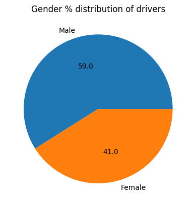

```python
temp_df = df.groupby('Driver_ID').agg({'Gender':'first'})
temp_df['Gender'].value_counts().plot(kind='pie', autopct='%.1f')
plt.title('Gender % distribution of drivers')
plt.ylabel('')
plt.show()
```

### Insight

- **59%** of the drivers are **Male** and remaining **41%** are **Female**

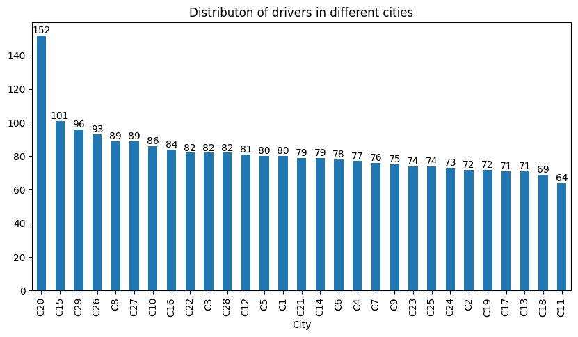

```python
plt.figure(figsize=(10,5))
temp_df = df.groupby('Driver_ID').agg({'City':'first'})
ax = temp_df['City'].value_counts().plot(kind='bar')
ax.bar_label(ax.containers[0])
plt.title('Distributon of drivers in different cities')
plt.show()
```

### Insight

- City **C20** has the **maximum** number of **drivers** followed by city C15

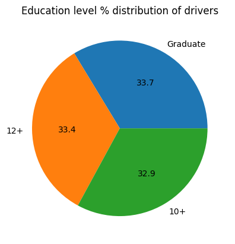

```python
temp_df = df.groupby('Driver_ID').agg({'Education_Level':'first'})
temp_df['Education_Level'].value_counts().plot(kind='pie', autopct='%.1f')
plt.ylabel('')
plt.title('Education level % distribution of drivers')
plt.show()
```

### Insight

- Almost equal proportion of drivers are from the 3 different education level

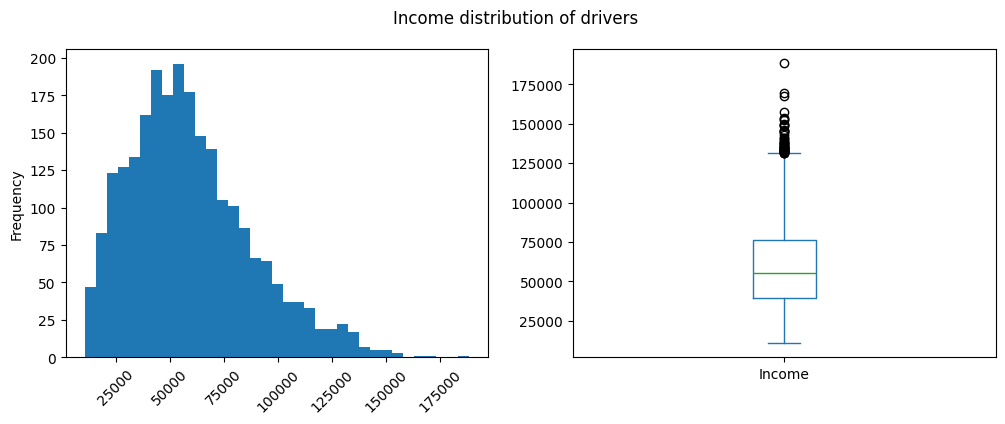

```python
fig, axs = plt.subplots(1,2,figsize=(12,4))
temp_df = df.groupby('Driver_ID').agg({'Income':'last'})['Income']
temp_df.plot(ax=axs[0], kind='hist', bins=35, rot=45)
temp_df.plot(ax=axs[1], kind='box')
fig.suptitle('Income distribution of drivers')
plt.show()
```

### Insight

- Most of the drivers have an average monthly income of **40k to 75k**
- The distribution is **right skewed**

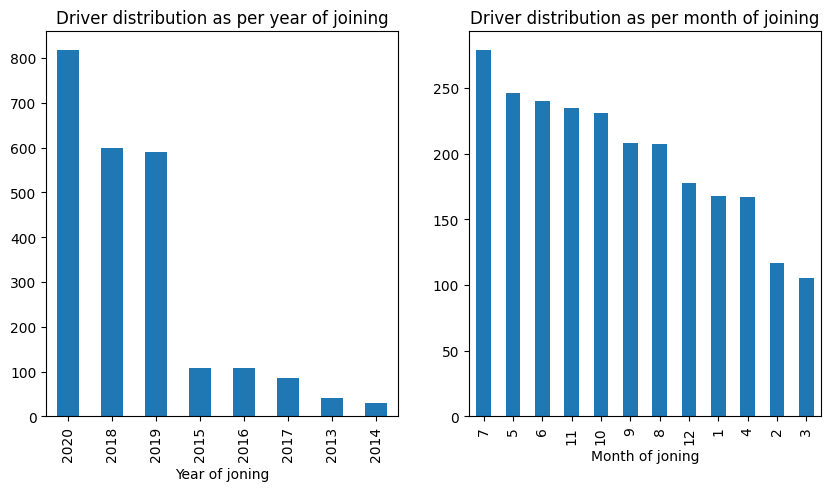

```python
temp_df = df.groupby('Driver_ID').agg({'Dateofjoining':'first'})['Dateofjoining']
fig, axs = plt.subplots(1,2,figsize=(10,5))
temp_df.dt.year.value_counts().plot(kind='bar', ax=axs[0], xlabel='Year of joning', title='Driver distribution as per year of joining')
temp_df.dt.month.value_counts().plot(kind='bar', ax=axs[1], xlabel='Month of joning', title='Driver distribution as per month of joining')
plt.show()
```

### Insight

- Maximum number of drivers joined in the year **2020**
- Maximum number of drivers joined in the month of **July**

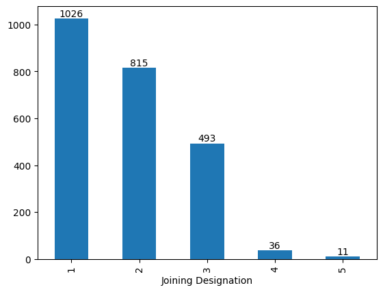

```python
ax = df.groupby('Driver_ID').agg({'Joining Designation':'first'})['Joining Designation'].value_counts().plot(kind='bar')
ax.bar_label(ax.containers[0])
plt.show()
```

### Insight

- Maximum number of drivers, 1026, have a **joining designation of 1**

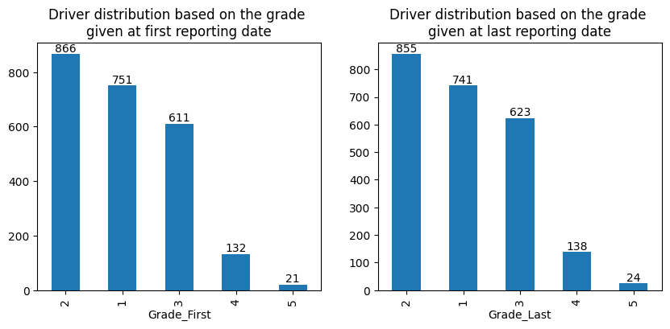

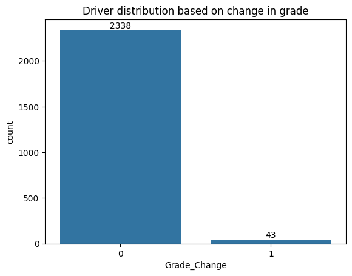

```python
temp_df_1 = df.groupby('Driver_ID').agg({'Grade':'first'}).reset_index()
temp_df_1.rename(columns = {'Grade':'Grade_First'}, inplace=True)
temp_df_2 = df.groupby('Driver_ID').agg({'Grade':'last'}).reset_index()
temp_df_2.rename(columns = {'Grade':'Grade_Last'}, inplace=True)
temp_df = pd.merge(temp_df_1, temp_df_2, on='Driver_ID')
temp_df['Grade_Change'] = temp_df['Grade_Last'].astype('int') - temp_df['Grade_First'].astype('int')
fig, axs = plt.subplots(1,2,figsize=(10,4))
ax = temp_df['Grade_First'].value_counts().plot(kind='bar', ax=axs[0], title='Driver distribution based on the grade \ngiven at first reporting date')
ax.bar_label(ax.containers[0])
ax = temp_df['Grade_Last'].value_counts().plot(kind='bar', ax=axs[1], title='Driver distribution based on the grade \ngiven at last reporting date')
ax.bar_label(ax.containers[0])
plt.show()
ax = sns.countplot(data=temp_df, x = 'Grade_Change')
ax.set_title('Driver distribution based on change in grade')
ax.bar_label(ax.containers[0])
plt.show()
```

### Insight

- Maximum number of drivers have a **grade of 2** and it doesnt change for the majority of the drivers

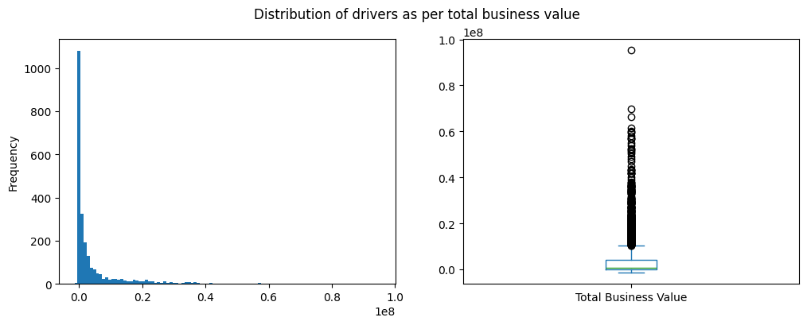

```python
fig, axs = plt.subplots(1,2,figsize=(12,4))
temp_df = df.groupby('Driver_ID').agg({'Total Business Value':'sum'})['Total Business Value']
temp_df.plot(ax=axs[0], kind='hist', bins=100)
temp_df.plot(ax=axs[1], kind='box')
fig.suptitle('Distribution of drivers as per total business value')
plt.show()
```

### Insight

- It is very evident that **many drivers** have a **total business value of 0** and there are also a few drivers who have a -ve business value
- The distribution is extremely **right skewed**

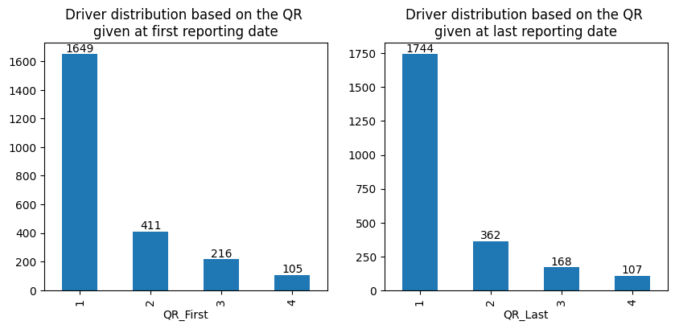

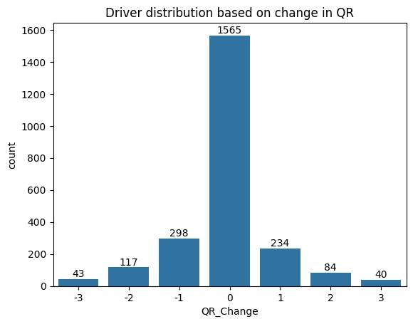

```python
temp_df_1 = df.groupby('Driver_ID').agg({'Quarterly Rating':'first'}).reset_index()
temp_df_1.rename(columns = {'Quarterly Rating':'QR_First'}, inplace=True)
temp_df_2 = df.groupby('Driver_ID').agg({'Quarterly Rating':'last'}).reset_index()
temp_df_2.rename(columns = {'Quarterly Rating':'QR_Last'}, inplace=True)
temp_df = pd.merge(temp_df_1, temp_df_2, on='Driver_ID')
temp_df['QR_Change'] = temp_df['QR_Last'].astype('int') - temp_df['QR_First'].astype('int')
fig, axs = plt.subplots(1,2,figsize=(10,4))
ax = temp_df['QR_First'].value_counts().plot(kind='bar', ax=axs[0], title='Driver distribution based on the QR \ngiven at first reporting date')
ax.bar_label(ax.containers[0])
ax = temp_df['QR_Last'].value_counts().plot(kind='bar', ax=axs[1], title='Driver distribution based on the QR \ngiven at last reporting date')
ax.bar_label(ax.containers[0])
plt.show()
ax = sns.countplot(data=temp_df, x = 'QR_Change')
ax.set_title('Driver distribution based on change in QR')
ax.bar_label(ax.containers[0])
plt.show()
```

### Insight

- **Majority** of the drivers have a very **low quarterly rating of 1**
- The change in QR plot shows that **majority** of the drivers **don't see a change in their QR** but there are **decent number** of drivers with **positive change in QR** and equally decent number of drivers with **negative change in QR**
- There are **no drivers** with QR of **5**

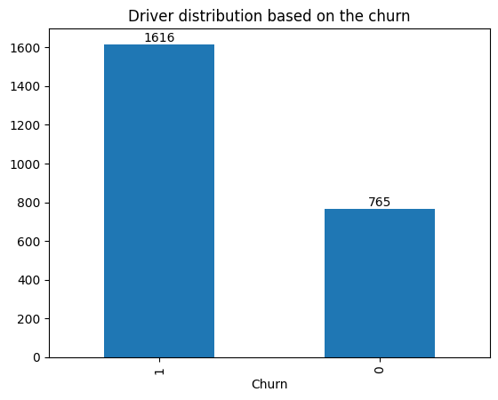

```
Churn
1    68.0
0    32.0
Name: proportion, dtype: float64
```

```python
temp_df = df.groupby('Driver_ID').agg({'Churn':'first'})['Churn']
ax = temp_df.value_counts().plot(kind='bar', title='Driver distribution based on the churn')
ax.bar_label(ax.containers[0])
plt.show()
(temp_df.value_counts(normalize=True)*100).round(0)
```

### Insight

- **1616** drivers have **churned**, which is around **68%**

## 4.2. Bivariate analysis

```python
driver_df = df.groupby('Driver_ID').agg({
    'ReportingMonthYear' : len,
    'Age' : 'last',
    'Gender' : 'first',
    'City' : 'first',
    'Education_Level' : 'first',
    'Income' : 'last',
    'Dateofjoining' : 'first',
    'LastWorkingDate' : 'last',
    'Joining Designation' : 'first',
    'Grade' : 'last',
    'Total Business Value' : 'sum',
    'Quarterly Rating' : 'last',
    'Churn':'last'
}).reset_index()
driver_df.rename(columns={'ReportingMonthYear': 'Months of Service'}, inplace=True)
driver_df.head(10)
```

|  | Driver_ID | Months of Service | Age | Gender | City | Education_Level | Income | Dateofjoining | LastWorkingDate | Joining Designation | Grade | Total Business Value | Quarterly Rating | Churn |
| --- | --- | --- | --- | --- | --- | --- | --- | --- | --- | --- | --- | --- | --- | --- |
| 0 | 1 | 3 | 28.0 | Male | C23 | Graduate | 57387 | 2018-12-24 | 2019-11-03 | 1 | 1 | 1715580 | 2 | 1 |
| 1 | 2 | 2 | 31.0 | Male | C7 | Graduate | 67016 | 2020-06-11 | NaT | 2 | 2 | 0 | 1 | 0 |
| 2 | 4 | 5 | 43.0 | Male | C13 | Graduate | 65603 | 2019-07-12 | 2020-04-27 | 2 | 2 | 350000 | 1 | 1 |
| 3 | 5 | 3 | 29.0 | Male | C9 | 10+ | 46368 | 2019-09-01 | 2019-07-03 | 1 | 1 | 120360 | 1 | 1 |
| 4 | 6 | 5 | 31.0 | Female | C11 | 12+ | 78728 | 2020-07-31 | NaT | 3 | 3 | 1265000 | 2 | 0 |
| 5 | 8 | 3 | 34.0 | Male | C2 | 10+ | 70656 | 2020-09-19 | 2020-11-15 | 3 | 3 | 0 | 1 | 1 |
| 6 | 11 | 1 | 28.0 | Female | C19 | Graduate | 42172 | 2020-07-12 | NaT | 1 | 1 | 0 | 1 | 0 |
| 7 | 12 | 6 | 35.0 | Male | C23 | Graduate | 28116 | 2019-06-29 | 2019-12-21 | 1 | 1 | 2607180 | 1 | 1 |
| 8 | 13 | 23 | 31.0 | Male | C19 | Graduate | 119227 | 2015-05-28 | 2020-11-25 | 1 | 4 | 10213040 | 1 | 1 |
| 9 | 14 | 3 | 39.0 | Female | C26 | 10+ | 19734 | 2020-10-16 | NaT | 3 | 3 | 0 | 1 | 0 |

```python
drivers_with_2_year_service = driver_df[driver_df['Months of Service'] == 24]['Driver_ID'].reset_index(drop=True)
```

```python
def calculate_change(df, column_name):
    temp_df_1 = df.groupby('Driver_ID').agg({column_name:'first'}).reset_index()
    first_column_name = column_name+'_First'
    temp_df_1.rename(columns = {column_name:first_column_name}, inplace=True)
    temp_df_2 = df.groupby('Driver_ID').agg({column_name:'last'}).reset_index()
    last_column_name = column_name+'_Last'
    temp_df_2.rename(columns = {column_name:last_column_name}, inplace=True)
    temp_df = pd.merge(temp_df_1, temp_df_2, on='Driver_ID')
    temp_df[column_name+'_Change'] = temp_df[last_column_name].astype('int') - temp_df[first_column_name].astype('int')
    temp_df.drop(columns=[first_column_name, last_column_name], inplace=True)
    return temp_df
```

```python
column_name = 'Income'
temp_df1 = calculate_change(df, 'Income')
driver_df = pd.merge(driver_df, temp_df1, on='Driver_ID')
temp_df2 = calculate_change(df, 'Grade')
driver_df = pd.merge(driver_df, temp_df2, on='Driver_ID')
temp_df3 = calculate_change(df, 'Quarterly Rating')
driver_df = pd.merge(driver_df, temp_df3, on='Driver_ID')
driver_df['Quarterly Rating Improved'] = driver_df['Quarterly Rating_Change'].apply(lambda x: 1 if x>0 else 0)
driver_df.head()
```

|  | Driver_ID | Months of Service | Age | Gender | City | Education_Level | Income | Dateofjoining | LastWorkingDate | Joining Designation | Grade | Total Business Value | Quarterly Rating | Churn | Income_Change | Grade_Change | Quarterly Rating_Change | Quarterly Rating Improved |
| --- | --- | --- | --- | --- | --- | --- | --- | --- | --- | --- | --- | --- | --- | --- | --- | --- | --- | --- |
| 0 | 1 | 3 | 28.0 | Male | C23 | Graduate | 57387 | 2018-12-24 | 2019-11-03 | 1 | 1 | 1715580 | 2 | 1 | 0 | 0 | 0 | 0 |
| 1 | 2 | 2 | 31.0 | Male | C7 | Graduate | 67016 | 2020-06-11 | NaT | 2 | 2 | 0 | 1 | 0 | 0 | 0 | 0 | 0 |
| 2 | 4 | 5 | 43.0 | Male | C13 | Graduate | 65603 | 2019-07-12 | 2020-04-27 | 2 | 2 | 350000 | 1 | 1 | 0 | 0 | 0 | 0 |
| 3 | 5 | 3 | 29.0 | Male | C9 | 10+ | 46368 | 2019-09-01 | 2019-07-03 | 1 | 1 | 120360 | 1 | 1 | 0 | 0 | 0 | 0 |
| 4 | 6 | 5 | 31.0 | Female | C11 | 12+ | 78728 | 2020-07-31 | NaT | 3 | 3 | 1265000 | 2 | 0 | 0 | 0 | 1 | 1 |

```python
driver_df['Income_Raise'] = driver_df['Income_Change'].apply(lambda x: 1 if x>0 else 0)
```

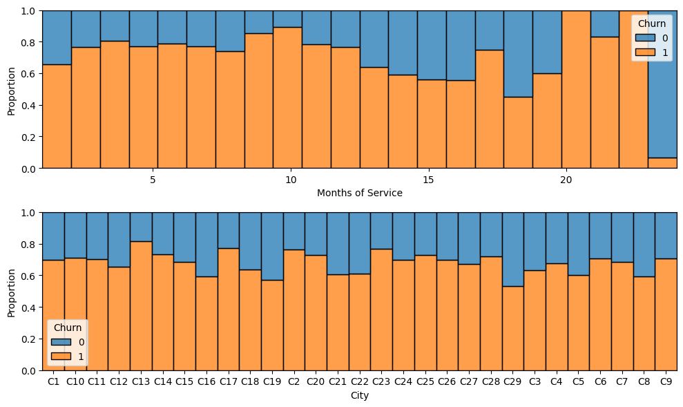

```python
fig, axs = plt.subplots(2,1,figsize=(10,6))
sns.histplot(ax = axs[0], data=driver_df, x='Months of Service', hue='Churn', stat="proportion", multiple="fill")
sns.histplot(ax = axs[1], data=driver_df, x='City', hue='Churn', stat="proportion", multiple="fill")
plt.tight_layout()
plt.show()
```

### Insight

- The **churn** rate is generally **higher** in drivers with **less months of service** and low in drivers with longer months of service with exception for 21, 22 and 23 months of service where the churn rates seems to be very high
- The city **C13** has the **highest churn rate** and city **C29** has the **lowest churn rate**

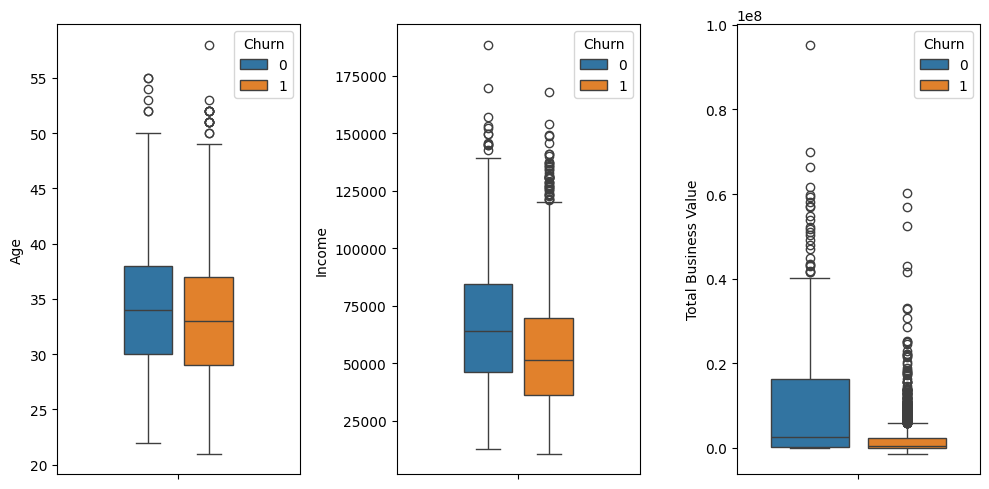

```python
fig, axs = plt.subplots(1,3,figsize=(10,5))
sns.boxplot(ax=axs[0], data=driver_df, y='Age', hue='Churn', width=0.5, gap=0.2)
sns.boxplot(ax=axs[1], data=driver_df, y='Income', hue='Churn', width=0.5, gap=0.2)
sns.boxplot(ax=axs[2], data=driver_df, y='Total Business Value', hue='Churn', gap=0.2)
plt.tight_layout()
plt.show()
```

### Insight

- The **median age** of drivers who have **churned** is **slighly lesser** than that of the drivers who have not churned
- The **median income** of drivers who have **churned** is **lesser** than that of the drivers who have not churned
- The **median Total Bussiness Value** of drivers who have **churned** is **lesser** than that of the drivers who have not churned
- The drivers who have **churned** also had **-ve Total Bussiness Value**

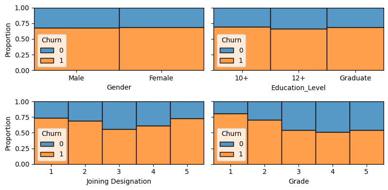

```python
fig, axs = plt.subplots(2,2,figsize=(8,4),sharey=True)
sns.histplot(ax=axs[0,0], data=driver_df, x='Gender', hue='Churn', stat="proportion", multiple="fill")
sns.histplot(ax=axs[0,1], data=driver_df, x='Education_Level', hue='Churn', stat='proportion', multiple='fill')
sns.histplot(ax=axs[1,0], data=driver_df, x='Joining Designation', hue='Churn', stat='proportion', multiple='fill')
sns.histplot(ax=axs[1,1], data=driver_df, x='Grade', hue='Churn', stat='proportion', multiple='fill')
plt.tight_layout()
plt.show()
```

### Insight

- The **churn** rate is **almost equal** in both **male and female** drivers
- The **churn** rate is **almost equal** in **10+ and Graduates** and slighly **lower** in **12+**
- The **churn** rate is **less** for **joining designation 3**
- The **churn** rate is **less** for **higher grades**

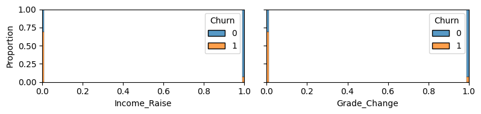

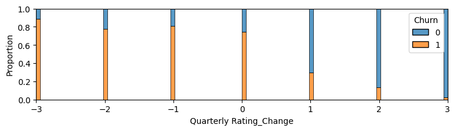

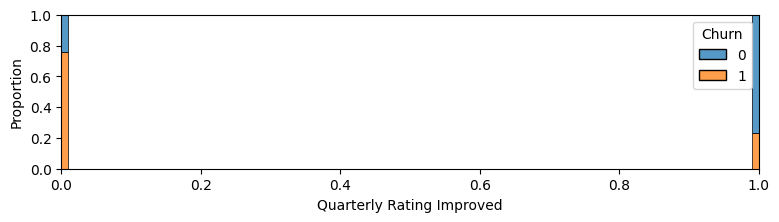

```python
fig, axs = plt.subplots(1,2,figsize=(8,2),sharey=True)
sns.histplot(ax=axs[0], data=driver_df, x='Income_Raise', hue='Churn', stat='proportion', multiple='fill')
sns.histplot(ax=axs[1], data=driver_df, x='Grade_Change', hue='Churn', stat='proportion', multiple='fill')
plt.tight_layout()
plt.show()
plt.figure(figsize=(9,2))
sns.histplot(data=driver_df, x='Quarterly Rating_Change', hue='Churn', stat='proportion', multiple='fill')
plt.show()
plt.figure(figsize=(9,2))
sns.histplot(data=driver_df, x='Quarterly Rating Improved', hue='Churn', stat='proportion', multiple='fill')
plt.show()
```

### Insight

- The **churn rate** is **very less** in drivers whose **income has raised**
- The **churn rate** is **very less** in drivers whose **grade has raised**
- The **churn rate** is **very less** in drivers whose **Quarterly rating has increased**

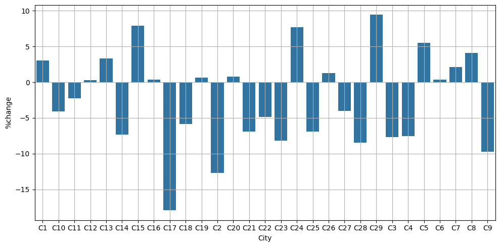

```python
temp_df = df.groupby(['City', 'ReportingYear']).agg({'Quarterly Rating': 'mean'}).reset_index()
temp_df1 = pd.pivot_table(data=temp_df, index='City', columns='ReportingYear', values='Quarterly Rating').reset_index()
temp_df1.rename(columns={'ReportingYear':'index', 2019:'2019', 2020:'2020'}, inplace=True)
temp_df1['%change'] = (((temp_df1['2020'] - temp_df1['2019'])/temp_df1['2019'])*100).round(2)
plt.figure(figsize=(10,5))
sns.barplot(data=temp_df1, x='City', y='%change')
plt.tight_layout()
plt.grid(True)
plt.show()
```

### Insight

- The city **C29** shows most improvement in Quarterly Rating in 2020 compared to 2019

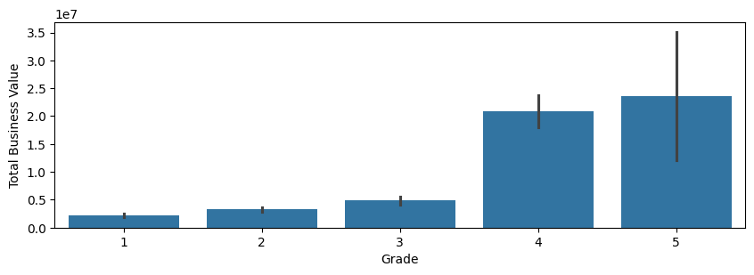

[output not shown]

```python
plt.figure(figsize=(10,3))
sns.barplot(data=driver_df, x='Grade', y='Total Business Value', estimator='mean')
plt.show()
print('Mean of Total Business Value of drivers with grade 5:', driver_df[driver_df['Grade'] == 5]['Total Business Value'].sum())
```

### Insight

- The mean of Total Business Value of drivers with grade 5 is higher than those with other grades

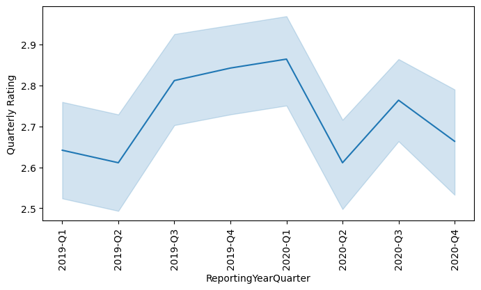

```python
def convert_to_year_quarter(x):
    year = str(x.year)
    month = x.month
    if(month >=1 and month <=3):
        return year+'-Q1'
    elif(month >=4 and month <=6):
        return year+'-Q2'
    elif(month >=7 and month <=9):
        return year+'-Q3'
    else:
        return year+'-Q4'

temp_df = df.copy()
temp_df['ReportingYearQuarter']=temp_df['ReportingMonthYear'].apply(convert_to_year_quarter)
temp_df.head()
temp_driver_full_service_df = temp_df[temp_df['Driver_ID'].isin(drivers_with_2_year_service)].groupby(['Driver_ID', 'ReportingYearQuarter']).agg({'Quarterly Rating':'last', 'Total Business Value':'sum'}).reset_index()
plt.figure(figsize=(8,4))
sns.lineplot(data=temp_driver_full_service_df, x='ReportingYearQuarter', y='Quarterly Rating')
plt.xticks(rotation=90)
plt.show()
```

### Insight

- There is a dip in the quarterly rating in Q2 and then it increases in Q3.
- This pattern can be osberved for both the years